# ggplot2_line

### 선그래프(Line Chart) 그리기

시간에 따라 달라지는 데이터를 표현할 때 주로 선 그래프를 이용함.  
일별환율처름 일정 시간간격을 주고 나열된 데이터를 ‘시계열 데이터(Time Series Data)’ 라고 하고,  
시계열 데이터를 선으로 표현한 그래프를 ‘시계열 그래프(Time Series Chart)’ 라고 함.

- ggplot2내의 economics 는 미국의 경제 지표들을 월별로 나타낸 데이터.

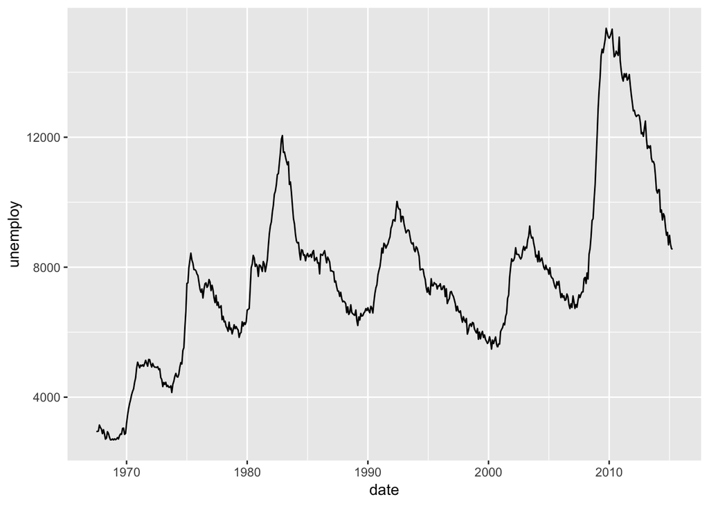

```r
library(ggplot2)
ggplot(economics, aes(x = date, y = unemploy)) +
  geom_line()
```

#### Q1.

psavert(개인 저축률)가 시간에 따라 어떻게 변해왔는지 알아보려고 합니다. 시간에 따른 개인 저축률의 변화를 나타낸 시계열 그래프를 만들어 보세요.

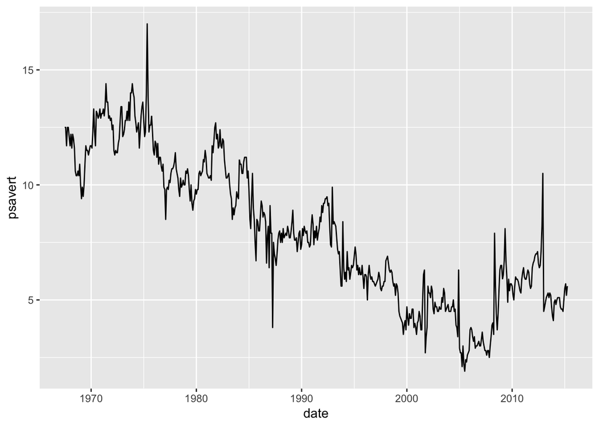

```r
ggplot(economics, aes(x = date, y = psavert)) +
  geom_line()
```

선그래프는 전형적으로 x축 상의 연속변수의 변화에 따른 y축 상의 연속변수를 시각화할 때 사용함.

#### 선그래프에 데이터 점 추가하기

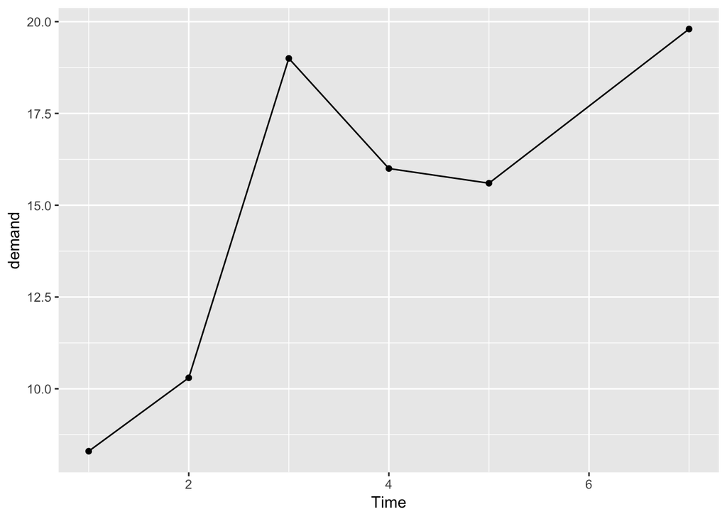

```r
ggplot(BOD, aes(x = Time, y = demand)) +
  geom_line() +
  geom_point()
```

#### 여러개의 선을 넣은 그래프 그리기

x축과 y축에 대입한 변수 이외에 다른 변수(이산)를 colour 또는 linetype에 대입한다.

```r
library(dplyr)
```

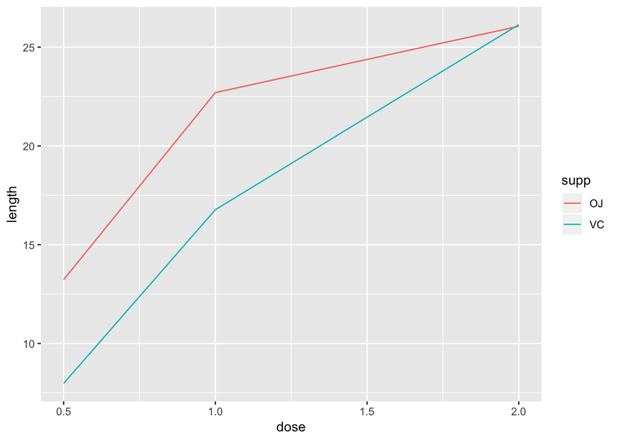

```r
tg <- ToothGrowth %>%
  group_by(supp, dose) %>%
  summarise(length = mean(len))

ggplot(tg, aes(x = dose, y = length, colour = supp)) +
  geom_line()
```

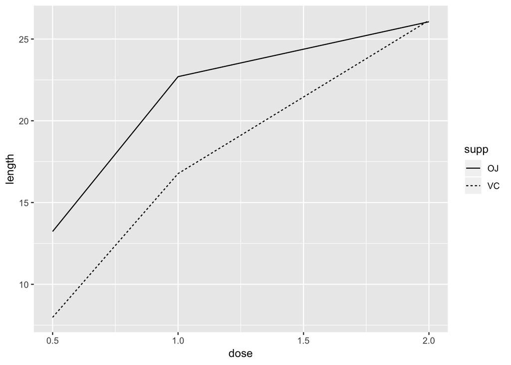

```r
ggplot(tg, aes(x = dose, y = length, linetype = supp)) +
  geom_line()
```

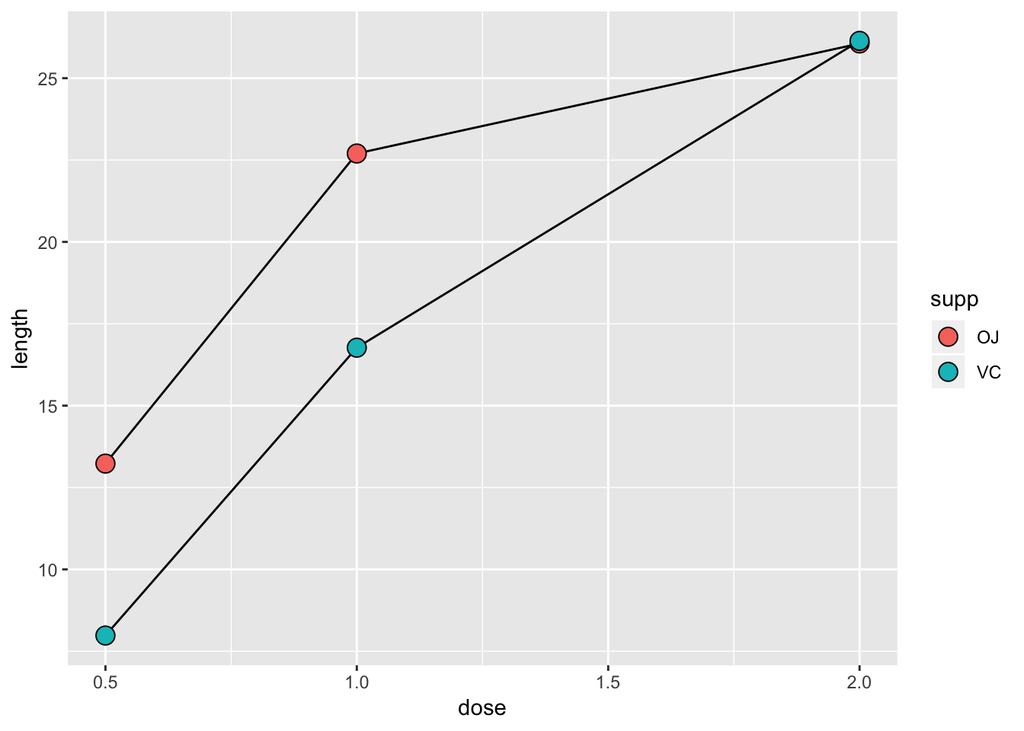

```r
ggplot(tg, aes(x = dose, y = length, fill = supp)) +
  geom_line() +
  geom_point(size = 4, shape = 21)
```

#### 선의 외형 변경하기

- 선의 종류는 linetype 으로 설정
- 선의 두깨(mm)는 size 로 설정
- 선의 색깔은 colour 로 설정

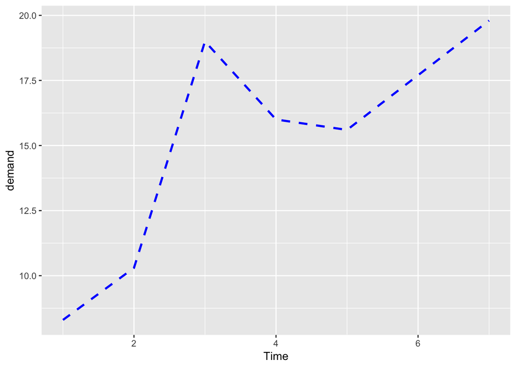

```r
ggplot(BOD, aes(x = Time, y = demand)) +
  geom_line(linetype = "dashed", size = 1, colour = "blue")
```

#### 그래프 영역에 음영 넣기

geom_area()를 사용해서 음영영역을 만듬.

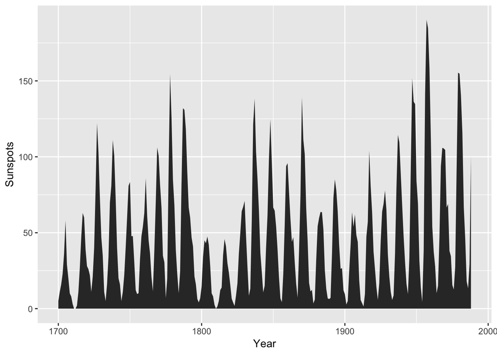

```r
sunspotyear <- data.frame(Year = as.numeric(time(sunspot.year)),
                          Sunspots = as.numeric(sunspot.year))
ggplot(sunspotyear, aes(x = Year, y = Sunspots)) +
  geom_area()
```

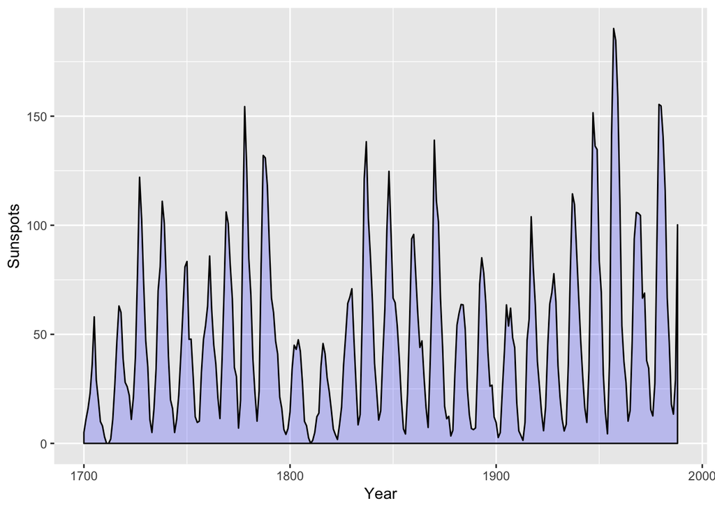

```r
ggplot(sunspotyear, aes(x = Year, y = Sunspots)) +
  geom_area(colour = "black", fill = "blue", alpha = .2)
```

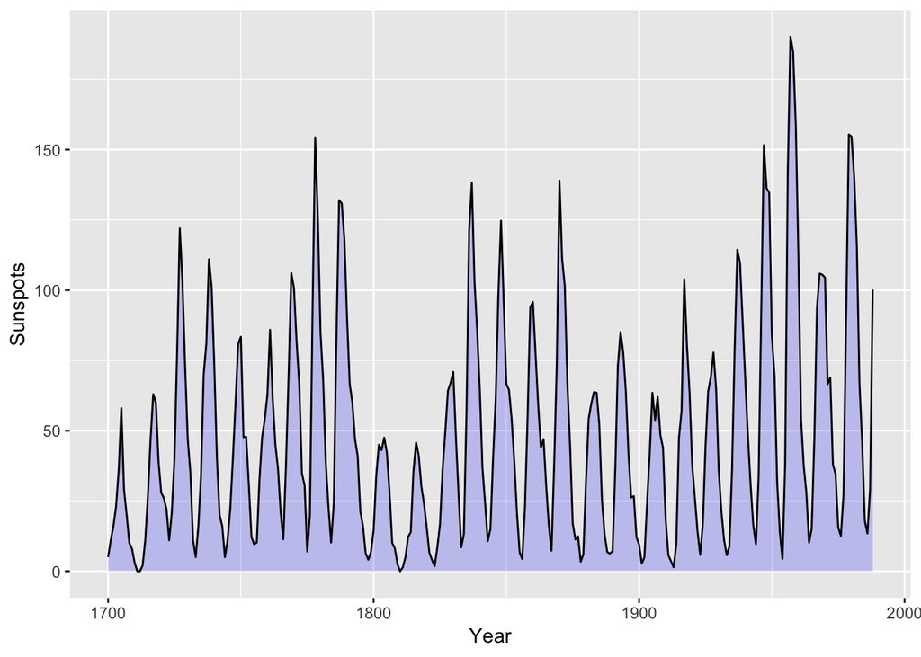

```r
ggplot(sunspotyear, aes(x = Year, y = Sunspots)) +
  geom_area(fill = "blue", alpha = .2) +
  geom_line()
```

#### 누적영역 그래프 그리기

geom_area() 를 사용하고 fill 에 요인을 대입한다.

```r
library(gcookbook)
```

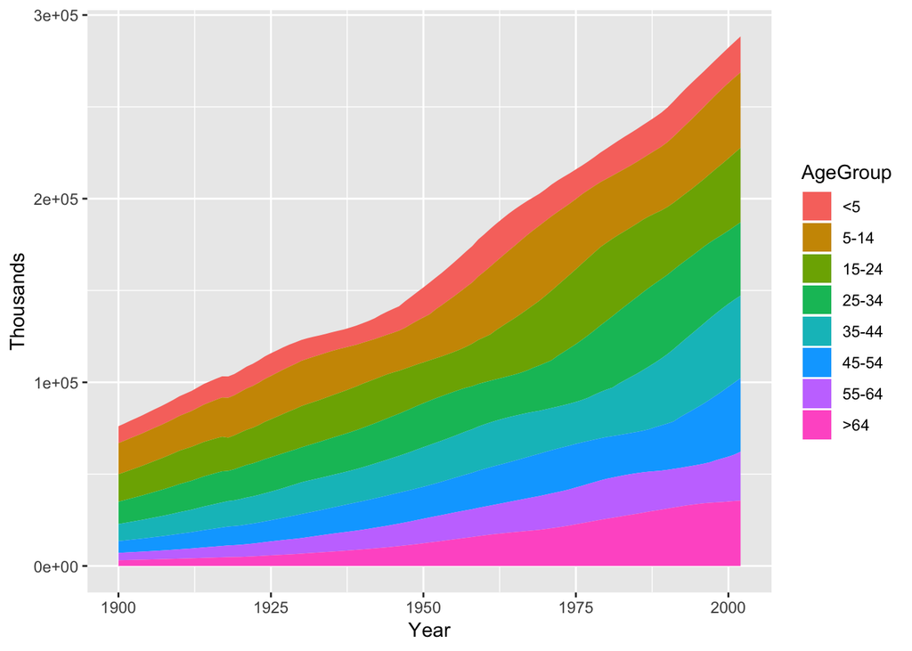

```r
ggplot(uspopage, aes(x = Year, y = Thousands, fill = AgeGroup)) +
  geom_area()
```

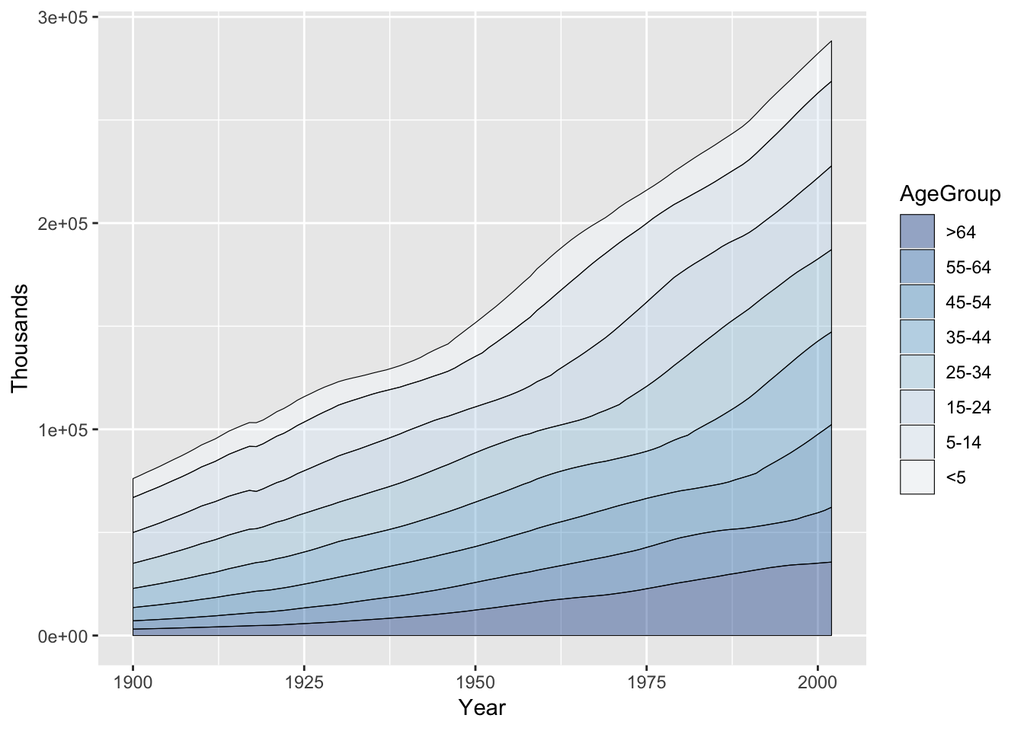

```r
ggplot(uspopage, aes(x = Year, y = Thousands, fill = AgeGroup)) +
  geom_area(colour = "black", size = .2, alpha = .4) +
  scale_fill_brewer(palette = "Blues", breaks = rev(levels(uspopage$AgeGroup)))
```